# Introduction to DSFDRC

```r
#loading all libraries
library(DSFDRC)
library(knockoff)
library(risksetROC)
library(dplyr)
library(tidyr)
library(survminer)
library(purrr)
```

## Background

In this document, we demonstrate a two-stage marginal screening (dual screening) procedure controlling false discovery rate (FDR) in the context of right censored cancer survival data. Our screening procedure uses the Conditional Characteristic Function as a measure of independence proposed by Ke & Yin (2019) and we name it as $\textit{kernel based independence dual screening}$ (KIDS) . To control the false discoveries in the screened predictors, we adopt the $\textbf{Knockoff}$ procedure proposed by Candes et al. (2018);which we name as the $\alpha$-$\textit{control kernel based independence dual screening}$ ($\alpha$-KIDS). Example data were obtained from the Cancer Genomic Atlas-Head and Neck Squamous Cell Carcinoma (TCGA-HNSCC) database [(TCGA-HNSCC)](https://portal.gdc.cancer.gov/projects/TCGA-HNSC)

## Head and Neck Squamous Cell Carcinoma Data

We downloaded upper quartile normalized RSEM TPM mRNA expression values for 518 primary-solid tumor samples from the TCGA-HNSCC data.Patients were subjected to right censoring (lost to follow up or no event until end of the study) with 57% censoring rate. Each patients were followed up from entry into the study until event/censorship. The observed time (survival/censored) ranged between 2 to 6417 days with a median of 649.5 days.

After some initial cleaning(removing identical and repeated columns and low expression values), we selected a total of 15,887 candidate genes and performed log transformation on them.For convenience, we skip the data processing step here and load the processed data:

```r
#loading the cleaned data
hnsc_data<-readRDS("hnsc_stand.rds")
dim(hnsc_data)
```

```
## [1]   518 15889
```

```
#> [1] 518 15889
```

```r
hnsc_data[c(1:10),c(1:10)]
```

|  | time | delta | A1BG | A2BP1 | A2LD1 | A2ML1 | A2M | A4GALT | A4GNT | AAA1 |
| --- | --- | --- | --- | --- | --- | --- | --- | --- | --- | --- |
| 1 | 102 | 0 | 1.38255406 | 1.4740603 | 0.4229328 | -0.04241633 | 1.06351309 | -0.002626395 | 1.230643480 | -0.5269464 |
| 2 | 462 | 1 | 1.41624051 | -0.4223261 | 0.2767616 | -1.29639387 | -1.10900558 | -0.586845120 | -0.196916036 | 0.2351675 |
| 3 | 283 | 1 | 0.43559236 | 0.2540377 | 1.2537111 | -2.21846801 | -1.70991143 | -0.721495199 | 0.007438391 | 0.4764168 |
| 4 | 415 | 1 | 0.67997860 | -0.9027300 | -0.3778906 | 0.51897171 | -1.46658172 | -0.798711492 | -0.007184209 | -0.5269464 |
| 5 | 1134 | 1 | 0.38056266 | -0.3440333 | 0.3798927 | -0.02124829 | -0.81266658 | 0.956785060 | 0.926962758 | 0.3914848 |
| 6 | 276 | 1 | 0.89530990 | -0.7588658 | -0.1729068 | -0.53944223 | 0.29842387 | -1.010587543 | 1.824716874 | -0.5269464 |
| 7 | 806 | 1 | 0.02560579 | -0.2790803 | -2.0697231 | -1.44055057 | -0.30356360 | -2.024317589 | -0.842477766 | -0.5269464 |
| 8 | 722 | 0 | -1.08179298 | -0.9027300 | 1.3876370 | 0.78637436 | 0.92012772 | -1.528903309 | 0.004470849 | -0.5269464 |
| 9 | 1288 | 0 | -0.42232945 | 1.4882568 | 1.3301767 | 0.43368331 | 0.06471936 | 2.332078809 | 0.094581151 | 0.9830684 |
| 10 | 1762 | 1 | 0.36366205 | -0.9027300 | 0.2395405 | 0.13219770 | 0.23853310 | 0.489187481 | 0.901187835 | -0.5269464 |

We see the first 10 rows and columns of the hnsc data. The first two columns show the “time” and “delta” respectively with delta=1 be the event (death). The rest of the columns are the mRNA gene expression covariates.

Assuming only a subset of the genes are associated with the overall survival, we will try to figure out the active set of genes first using our screening only method: $\textbf{KIDS}$ (kernel-based independence dual screening) followed by screening with FDR control method: $\mathbf{\alpha-KIDS}$ ($\alpha$ controlled kernel-based independence dual sreening).We briefly describe the two procedures below:

## Dual Screening procedure:KIDS

Let us consider the survival time $T$, censoring time $C$, censoring indicator $\delta=I(T\leq C)$ and covariate matrix $\textbf{X}$, We only observe $Y=min(T,C)$. To measure the importance of any $X_j \in \textbf{X}$, we calculate two non-parametric kernel-based squared correlations following Ke and Yin (2019):

1. Correlation between $X_j$ and $\delta$, $\Omega_{j,1}=R^2_K(X_j|\delta)=\frac{\sum_{s=0,1}w_s\overline{K}_{j,s}-\overline{K}_j}{1-\overline{K}_j}$;
2. Correlation between $X_j$ and $Y$ given $\delta=s$, $\Omega_{j,2}=R^2_K(X_j|Y;\delta)=\frac{\sum_{s=0,1}w_s\mathcal{H}_{K,G_{h_s},n_s}^2(X_j|Y;\delta=s)}{1-\sum_{s=0,1}w_s\overline{K}_{j,s}}$.

with $\mathcal{H}_{K,G_{h_s},n_s}^2(X_j|Y;\delta=s)=\frac{1}{n_s} \sum_{i_1\in \mathcal{J}_s}\frac{\sum_{i_2,i_3\in \mathcal{J}_s}G_{h_s}(Y_{i_1}-Y_{i_2})G_{h_s}(Y_{i_1}-Y_{i_3})K(X_{i_2,j}-X_{i_3,j})}{\sum_{i_2,i_3\in\mathcal{J}_s}G_{h_s}(Y_{i_1}-Y_{i_2})G_{h_s}(Y_{i_1}-Y_{i_3})}- \overline{K}_{j,s}$.

These two correaltions were estimated using two kernels: a reproducing gaussian kernel K(.) and a smoothing kernel G(.). Details of this estimation procedure can be found in the paper.

After calculating $(\Omega_{j,1},\Omega_{j,2})$ , we rank the correlations and select top $d$ covariates as the important ones. One popular choice of $d$ can be $d_n=\frac{n}{log(n)}$ with $n$ be the sample size (Fan & Lv,2008). This dual screening procedure is performed on the TCGA-HNSC data below using the “KIDS” function:

```r
screen_result<-KIDS(x=hnsc_data[,-c(1,2)],#a matrix/data frame of covriates
                    y=hnsc_data$time, # a vector of time
                    delta= hnsc_data$delta # a vector of censoring indicator
                    )
```

The function will return a matrix of correlations and a list of covariate index ordered based on their importance. Based on the correlations, the index of top $d_n=\frac{n}{log(n)}=83$ are:

```r
top_cov<-screen_result$top_covariates[1:83]

colnames(hnsc_data)[top_cov]
```

[1] “MARVELD2” “MXRA7” “TMSB10” “LOC647946” “UGP2” “ZNF263” “COL27A1” “DVL2”  
[9] “KIAA0101” “CSMD2” “UTS2D” “SSX1” “C9ORF45” “SPN” “NR2C1” “PCDH8”  
[17] “CYYR1” “SLC7A1” “LCN1” “AMAC1L2” “C12ORF24” “SERTAD3” “MCFD2” “PNN”  
[25] “FCN1” “UGT2A3” “MEI1” “DNMT3A” “IGFN1” “LOC402377” “CD177” “ASGR2”  
[33] “MRTO4” “CCDC9” “TNFRSF13C” “ABCC6P1” “FLRT3” “PARVB” “METRN” “ACTA2”  
[41] “NLGN2” “USP8” “C3ORF55” “ITGB1” “FLJ37453” “SRD5A3” “GABRA3” “CELP”  
[49] “AQP1” “ELAVL1” “C3ORF23” “FAM161A” “BIVM” “CHRNE” “USP42” “MYH7”  
[57] “ECH1” “PLD6” “NCLN” “LILRB5” “DHRS12” “OLFML3” “TNFRSF11B” “SP140L”  
[65] “MFSD5” “CDYL” “BZW1” “SLC27A5” “CD72” “CEP78” “TTPAL” “TMSL3”  
[73] “MYL12A” “MFSD4” “SUSD5” “MRPS35” “ZNF81” “CXCL6” “ATP5H” “IMPG2”  
[81] “MYCBP” “MS4A8B” “ALOX12P2”

To retain the sure screening property,the dual screening procedure might include false discoveries. To control the false discoveries, we introduced aKIDS function using the knockoff counterpart of the predictors as negative control. Below we describe breifly the contruction of knockoffs followed by the algorithm for the “aKIDS” procedure.

## Screening with FDR control:$\alpha$-KIDS

#### Knockoff construction

$\tilde{\textbf{X}}=(\tilde{X_1},\tilde{X_2},...\tilde{X_p})$ is a knockoff copy of $\textbf{X}=(X_1, X_2,....X_p)$ if

- $\tilde{\textbf{X}} \perp \textbf{Y}|\textbf{X}$
- $f(\textbf{X},\tilde{\textbf{X}})=f(\tilde{\textbf{X}},\textbf{X})$ for the 1st two moments,
  - This can be done setting $Corr((\textbf{X}_j),(\tilde{\textbf{X}_j}))=1-min(2\lambda_{min}(\Sigma),1)$ where,$\lambda_{min}=$ minimum eigenvalue of $\Sigma=Cov(\textbf{X})$

The construction of above knockoff copies require $n>=2p$ where $p=$ no. of covariates.

#### Algorithm:

- Split the data into $n_1$ & $n_2$ with $n_1<n_2$

$\textbf{Screening-Step:}$

- Apply screening on $n_1$, select $d=\frac{n_1}{log(n_1)}$ covariates.

$\textbf{Knockoff-Step:}$

- Create $\tilde{\textbf{X}}_d^{(n_2)}$ of ${\textbf{X}_d}^{(n_2)}$
- Knockoff matrix, ${\tilde{\textbf{X}}_{d}}=\begin{bmatrix} \textbf{X}_{d}^{(n_1)} \\[5mm] \tilde{\textbf{X}}_{d}^{(n_2)} \end{bmatrix}$ of original ${\textbf{X}}_{d}=\begin{bmatrix} \textbf{X}_{d}^{(n_1)} \\[5mm] \textbf{X}_{d}^{(n_2)} \end{bmatrix}$
- For each $j\in ({\tilde{\textbf{X}}_{d}},{\textbf{X}}_{d})$,Calculate two feature statistics:
- $W_{1,j}=\Omega_{x_j,1}-\Omega_{\tilde{x_j},1}$
- $W_{2,j}=\Omega_{x_j,2}-\Omega_{\tilde{x_j},2}$
- For two given Thresholds $T_1$ & $T_2$ and a prespecified FDR $q$,obtain final active set of covariates,
  $$\hat{\mathcal{A}}_q=\{j:j\in d,W_{1,j}\ge T_1 \cup W_{2,j} \ge T_2\}$$
  where, $T=\mathrm{min}\{t\in|W_j|>0:\frac{\#\{j:W_j\le -t\}}{\#\{j:W_j> t\}}\le q \}$

We demonstrate the whole screening with FDR control procedure for our TCGA-HNSC data with the help of “aKIDS” function. The function will return a a list of active predictors while controlling the prespecified false discovery rate (FDR). The procedure is shown below:

```r
set.seed(4090)
akids_result<-a_KIDS(x=hnsc_data[,-c(1,2)],y=hnsc_data$time,delta=hnsc_data$delta,
                    n1=200,# desired sample size for the screening step
                    d=100, # selected predictor in the screening step
                    fdr=c(.10), # desired false discovery rate
                    swap=F)
akids_result
```

```
## [[1]]
##  [1]  5443  4116  3485  9660  7868  5958  2211 13218  1970 14728  2218
```

```r
final_var<-colnames(hnsc_data)[unlist(akids_result)]
final_var
```

```
##  [1] "G3BP2"     "DNMT3A"    "CSMD2"     "OLFML3"    "LOC647946" "GRPEL2"
##  [7] "C9ORF45"   "SSX1"      "C3ORF23"   "UGP2"      "C9ORF69"
```

In the aKIDS procedure, we get a final set of 11 gene expressions. Next, we fit a coxph model with the selected covariates and evaluate the predictive performance of the model based on the AUC values of 1-, 3- and 5- years survival.

```r
#####################ROC plot########################


fit_data<-hnsc_data[,c("time","delta",final_var)]
#fitting cox model
model1<-coxph(Surv(time,delta) ~ ., data =fit_data,x=T,y=T)
summary(model1)
```

```
## Call:
## coxph(formula = Surv(time, delta) ~ ., data = fit_data, x = T,
##     y = T)
##
##   n= 518, number of events= 220
##
##               coef exp(coef) se(coef)      z Pr(>|z|)
## G3BP2      0.08186   1.08531  0.07818  1.047   0.2950
## DNMT3A    -0.09437   0.90995  0.09261 -1.019   0.3082
## CSMD2     -0.08535   0.91819  0.09432 -0.905   0.3655
## OLFML3    -0.01885   0.98133  0.09288 -0.203   0.8392
## LOC647946  0.08704   1.09094  0.07424  1.172   0.2410
## GRPEL2    -0.11353   0.89268  0.08367 -1.357   0.1748
## C9ORF45   -0.17979   0.83545  0.07991 -2.250   0.0245 *
## SSX1       0.01582   1.01594  0.06346  0.249   0.8032
## C3ORF23   -0.06811   0.93415  0.07959 -0.856   0.3921
## UGP2       0.02405   1.02434  0.07280  0.330   0.7411
## C9ORF69   -0.04926   0.95193  0.08313 -0.593   0.5535
## ---
## Signif. codes:  0 '***' 0.001 '**' 0.01 '*' 0.05 '.' 0.1 ' ' 1
##
##           exp(coef) exp(-coef) lower .95 upper .95
## G3BP2        1.0853     0.9214    0.9311    1.2650
## DNMT3A       0.9099     1.0990    0.7589    1.0911
## CSMD2        0.9182     1.0891    0.7632    1.1046
## OLFML3       0.9813     1.0190    0.8180    1.1773
## LOC647946    1.0909     0.9166    0.9432    1.2618
## GRPEL2       0.8927     1.1202    0.7577    1.0518
## C9ORF45      0.8354     1.1970    0.7143    0.9771
## SSX1         1.0159     0.9843    0.8971    1.1505
## C3ORF23      0.9342     1.0705    0.7992    1.0919
## UGP2         1.0243     0.9762    0.8881    1.1814
## C9ORF69      0.9519     1.0505    0.8088    1.1204
##
## Concordance= 0.587  (se = 0.022 )
## Likelihood ratio test= 13.23  on 11 df,   p=0.3
## Wald test            = 13.23  on 11 df,   p=0.3
## Score (logrank) test = 13.23  on 11 df,   p=0.3
```

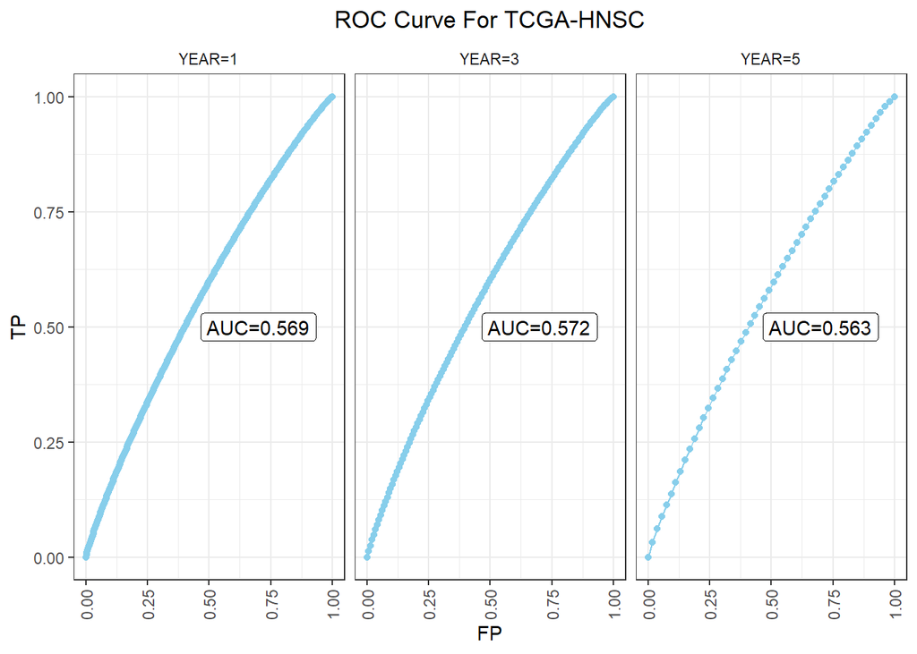

```r
# caclulating risk score as linear predictor
marker1<-predict(model1,newdata = fit_data,type="lp")

auc1<-risksetROC(Stime=fit_data$time, status=fit_data$delta,
                 marker=marker1, predict.time=365, method="Cox" ,plot =FALSE)$AUC #1year AUC

auc2<-risksetROC(Stime=fit_data$time, status=fit_data$delta,
                 marker=marker1, predict.time=1095, method="Cox" ,plot =FALSE)$AUC #3year AUC

auc3<-risksetROC(Stime=fit_data$time, status=fit_data$delta,
                 marker=marker1, predict.time=1825, method="Cox" ,plot =FALSE)$AUC #5year AUC


## Define a helper functio nto evaluate at var1ious t
risksetROC_helper <- function(t) {
  risksetROC(Stime        = fit_data$time,
             status       = fit_data$delta,
             marker       = marker1,
             predict.time = t,
             method       = "Cox",
             plot         = FALSE)
}
## Evaluate 1,3,5 years
risksetROC_data <- data_frame(t = 365 * c(1,3,5)) %>%
  mutate(risksetROC = map(t, risksetROC_helper),
         ## Extract scalar AUC
         auc = map_dbl(risksetROC, magrittr::extract2, "AUC"),
         ## Put cut off dependent values in a data_frame
         df_risksetROC = map(risksetROC, function(obj) {
           ## marker column is too short!
           marker <- c(-Inf, obj[["marker"]], Inf)
           bind_cols(data_frame(marker = marker),
                     as_data_frame(obj[c("TP","FP")]))
         })) %>%
  dplyr::select(-risksetROC) %>%
  unnest() %>%
  arrange(t, FP, TP)

## Plot
risksetROC_data %>%
  ggplot(mapping = aes(x = FP, y = TP)) +
  geom_point(color="skyblue") +
  geom_line(color="skyblue") +
  geom_label(data = risksetROC_data %>% dplyr::select(t,auc) %>% unique,
             mapping = aes(label = sprintf("AUC=%.3f", auc)), x = 0.7, y = 0.5) +
  facet_wrap( ~ sprintf("YEAR=%.0f", t/365)) +
  theme_bw() +
  theme(axis.text.x = element_text(angle = 90, vjust = 0.5),
        legend.key = element_blank(),
        plot.title = element_text(color="black",hjust = 0.5),
        strip.background = element_blank())+labs(title = "ROC Curve For TCGA-HNSC")
```

Finally, we divide the patients into “Low” and “High” Risk group based on the median risk score and plot KM plot to see if our model can significantly distinguish between the two groups.

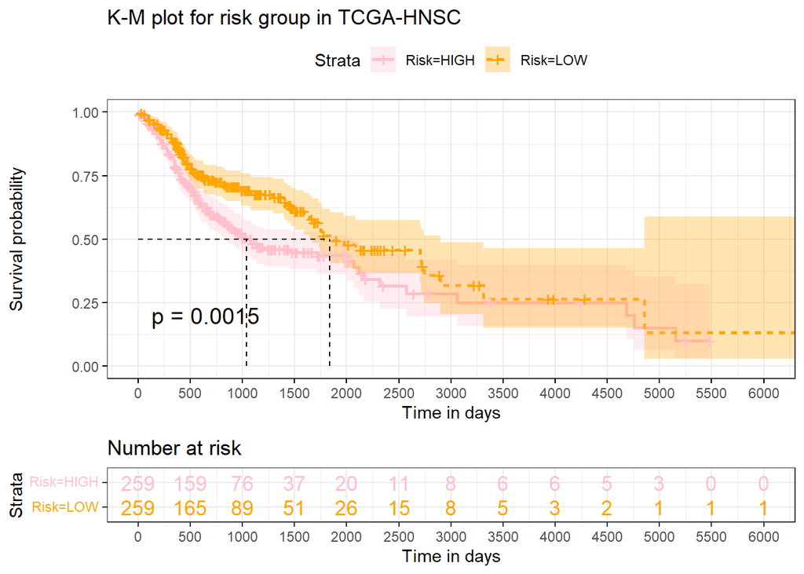

```r
fit_data$risk_score<-marker1
fit_data$Risk<-ifelse(fit_data$risk_score>=median(marker1),"HIGH","LOW")
fit <- survfit(Surv(time,delta)~Risk, data = fit_data)

ggsurvplot(fit,
           pval = TRUE, conf.int = TRUE,
           title="K-M plot for risk group in TCGA-HNSC",
           risk.table = TRUE, # Add risk table
           risk.table.col = "strata", # Change risk table color by groups
           xlab = "Time in days",   # customize X axis label.
           break.time.by = 500,
           linetype = "strata", # Change line type by groups
           surv.median.line = "hv", # Specify median survival
           ggtheme = theme_bw(), # Change ggplot2 theme

           palette = c("pink", "orange"))
```